# Data

## Stock Issuance Deals in the Sample

The stock issuance deals are extracted from SDC. The sample restriction includes:

```
1. Issuer from U.S.
2. Issued in U.S. stock market
3. Not from Financial Industry, Utility Industry, and Quasi-Government Industry
4. With information at least one of the filing date and issuing date
5. IPO flag is NO
```

The stock price history underlying each issuance deal is extracted from CRSP by using the CUSIP code reported by SDC data. Some issuances have the complete 8-digit CUSIP code and the search in CRSP is implemented with the 8-digit CUSIP code directly. For the issuance without the complete 8-digit CUSIP code, we use the first 6 digit of the CUSIP code to search in CRSP. If there is only one result returned, this returned price history will be assigned to this issuance deal. Otherwise, this issuance deal will be eliminated from the sample. In the end, there are 12313 observations in total. All of them have issuance date on record, but only 88.4% of them have filing date on record.

## Number of SEO Deals Across History

Based on the issuance date and filing date on record, the number of SEO deals within the sample can be aggregated to each calendar quarter. The history of the number of deals, as well as the change in the number of deals can be illustrated in the following graphs.

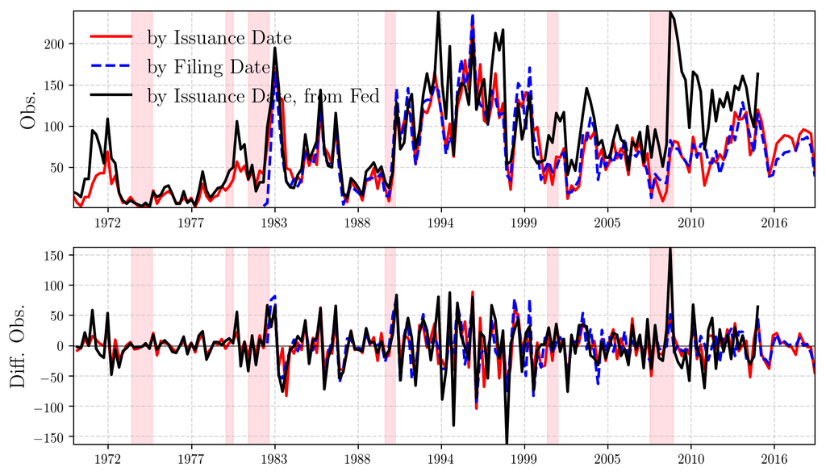

From the above graph, we can tell:

```
1. The total number of SEO deals reported by Fed Board, which is from Jay Ritter's website, is larger than the SEO numbers included in this sample, but their time-variations are very close to each other.
2. The deal numbers categorized by their issuance date and filing date are quite close to each other after 1983.
```

## Gap between Filiing Date and Issuance Date

This gap could be informative about the timing choices of issuance. Here, we calculate the number of business days between the Filing Date and the Issuance Date. Overall, there are not many deals with issuance right following the filing. But most of the deals are executed within a quarter after filing.

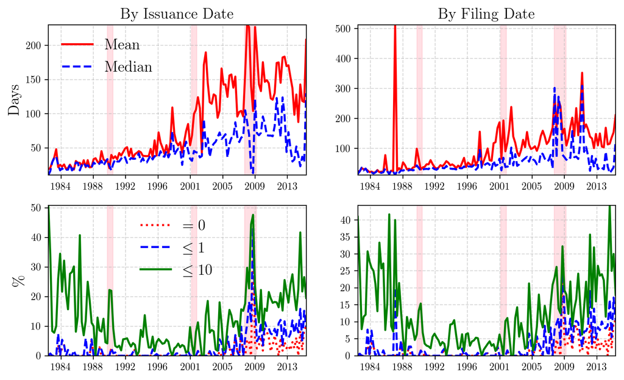

## Abnormal Return

### Individual Level

An one-factor model is estimated for each issuance deal $i$ over the period which starts from 140 trading days before the event date $ T_{i} $ and ends at 10 trading days after the event date: $$ \begin{equation} r_{i,T_{i}+\Delta t}-r_{f,T_{i}+\Delta t}=\alpha_{i}+\beta_{i}\cdot \left( r_{\texttt{sp}500,T_{i}+\Delta t}-r_{f,T_{i}+\Delta t} \right)+\varepsilon_{i,T_{i}+\Delta t}, \Delta t=-140,-139,\dots,10 \end{equation} $$

The estimated residual $ \hat{\varepsilon}_{i,T_{i}+\Delta t} $ is the abnormal return. There are two choices for the event date $ T_{i} $: the issuance date and filing date. For notation simplicity, the $ \textbf{abnormal return} (AR) $ on a specific day within the event window is denoted as $ \nu_{i,s}^{T}\equiv \hat{\varepsilon}_{i,T_{i}+s} $ and the $ \textbf{accumulated abnormal return (AAR) } $ over a period within the event window is denoted as $ \tilde{\nu}^{T}_{i,\underline{s},\bar{s}}\equiv \sum_{s=\underline{s}}^{\bar{s}} \nu^{T}_{i,s} $, where $ T=I $ when issuance date is chosen as the event date and $ T=F $ when filing date is chosen as the event date.

### Aggregate Level

With a panel of SEO deals and their abnormal return history in hand, we aggregate the individual level measures in two ways to study the statistical property of the abnormal return associated with the stock issuance.

#### Pooled Aggregation

Under this approach, the aggregate level evaluation of AR or AAR is constructed over the whole sample:

- Average or weighted average: $ \bar{x}=\dfrac{ \sum_{i} x_{i}\cdot \omega_{i} }{ \sum_{i} \omega_{i} } $, where $ x $ can be any AR or AAR variables and the weight $ \omega_{i} $ is the proceeds amount of each deal in real value.
- Standard deviation and quantiles are measured in the standard way over the whole sample.

#### Two-layer Aggregation

Under this approach, the AR or AAR are first aggregated within each calendar quarter. For deal $ i $ with event date $ T_{i} $, it will be assigned to the calendar quarter which date $ T_{i} $ belongs to. For each quarter, we first compute the average AR or AAR as: $$ \begin{equation} \bar{x}^{T}_{q}=\frac{ \sum_{i\in \{i: T_{i}\in q\} } x^{T}_{i}\cdot \omega_{i} }{ \sum_{i\in \{i: T_{i}\in q\} } \omega_{i} } \end{equation} $$ Then we calculate the non-weighted average, standard deviation and quantile of these quarterly-aggregated statistics.

### Event Study

#### Daily Abnormal Return within Event Window

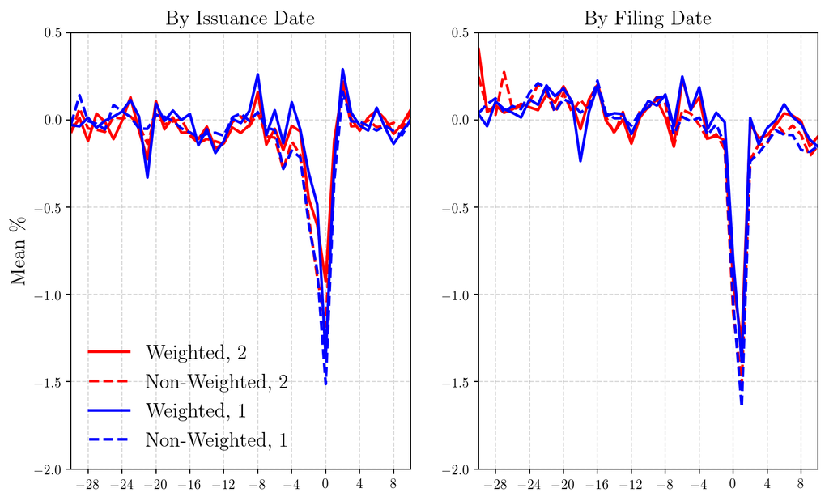

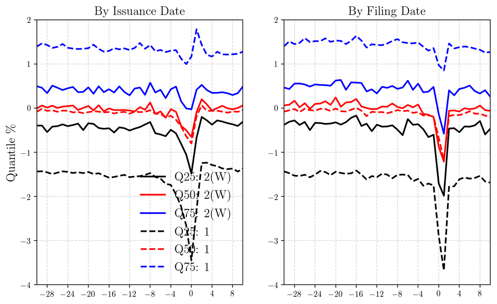

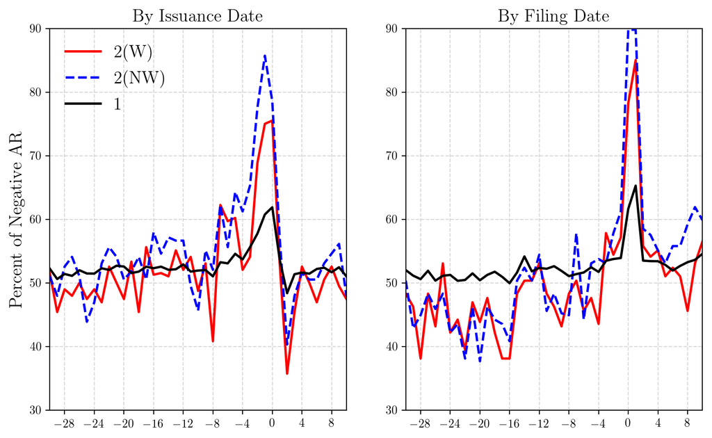

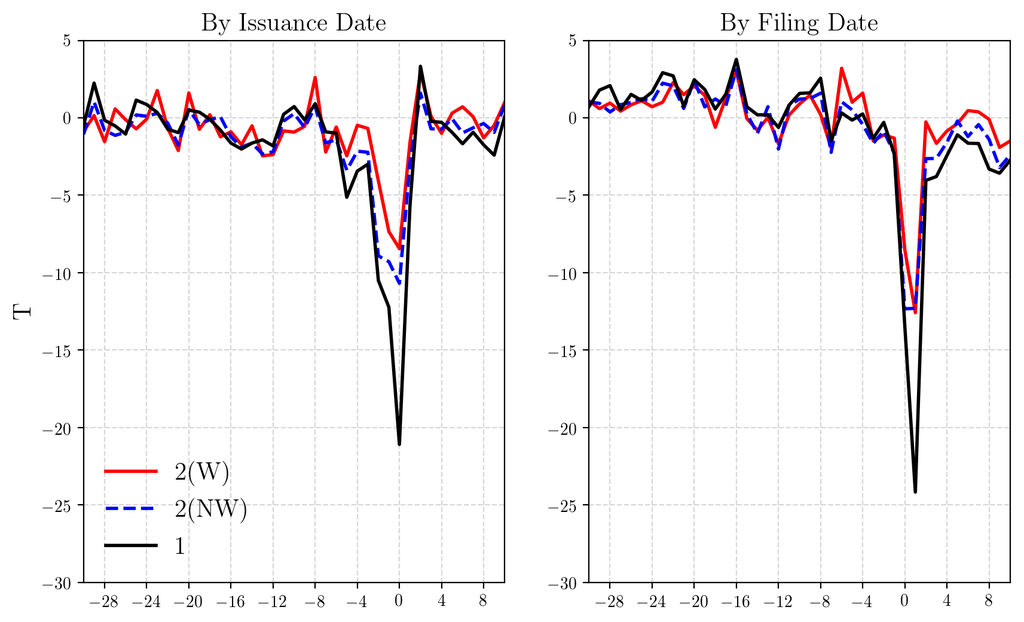

From the above graphs, we can see the significant price drop around the filing and issuance event.

#### Accumulated Return around the Event Date

| (AggType, ) | EventType EventDateStart EventDateEnd (Stat, ) | F -5 1 | F -4 1 | F -3 1 | F -2 1 | F -1 1 | F 0 1 | I -5 1 | I -4 1 | I -3 1 | I -2 1 | I -1 1 | I 0 1 |
| --- | --- | --- | --- | --- | --- | --- | --- | --- | --- | --- | --- | --- | --- |
| NQ | Max | 3.99 | 3.75 | 4.15 | 4.14 | 4.36 | 6.87 | 8.44 | 8.34 | 6.35 | 3.61 | 4.15 | 4.62 |
|  | Mean | -2.96 | -2.99 | -2.96 | -2.85 | -2.74 | -2.52 | -3.49 | -3.21 | -3.09 | -2.89 | -2.31 | -1.41 |
|  | Min | -11.63 | -13.28 | -9.64 | -9.45 | -12.55 | -11.67 | -15.47 | -14.78 | -14.43 | -14.53 | -14.42 | -16.13 |
|  | NegPct | 89.12 | 91.16 | 93.20 | 92.52 | 97.96 | 97.96 | 89.29 | 89.80 | 88.78 | 87.76 | 86.73 | 76.53 |
|  | Q25 | -4.81 | -4.68 | -4.50 | -3.90 | -3.57 | -3.43 | -5.64 | -5.04 | -4.82 | -4.40 | -3.70 | -2.41 |
|  | Q50 | -2.73 | -2.80 | -2.91 | -2.82 | -2.65 | -2.40 | -3.28 | -2.94 | -2.82 | -2.56 | -1.96 | -0.94 |
|  | Q75 | -1.41 | -1.37 | -1.51 | -1.57 | -1.60 | -1.74 | -1.34 | -1.17 | -1.24 | -1.11 | -0.61 | -0.03 |
|  | T | -13.91 | -14.38 | -15.88 | -16.89 | -17.55 | -17.52 | -14.55 | -14.56 | -14.99 | -14.85 | -12.54 | -8.58 |
| Pooled | Max | 294.22 | 294.93 | 278.43 | 303.55 | 340.97 | 457.43 | 182.46 | 172.07 | 157.10 | 100.80 | 106.07 | 46.96 |
|  | Mean | -2.92 | -2.91 | -2.91 | -2.83 | -2.78 | -2.58 | -4.04 | -3.75 | -3.58 | -3.36 | -2.75 | -1.89 |
|  | Min | -107.39 | -107.24 | -107.97 | -78.33 | -76.45 | -75.11 | -130.84 | -126.64 | -129.96 | -126.64 | -118.87 | -117.24 |
|  | NegPct | 65.17 | 66.48 | 67.39 | 68.82 | 69.23 | 70.34 | 64.81 | 64.65 | 64.55 | 65.54 | 63.84 | 60.42 |
|  | Q25 | -7.81 | -7.59 | -7.21 | -6.75 | -6.21 | -5.44 | -9.14 | -8.62 | -8.14 | -7.34 | -6.46 | -4.92 |
|  | Q50 | -2.71 | -2.72 | -2.69 | -2.64 | -2.38 | -2.13 | -2.92 | -2.71 | -2.59 | -2.42 | -1.94 | -1.20 |
|  | Q75 | 2.01 | 1.70 | 1.34 | 1.19 | 0.87 | 0.57 | 2.27 | 2.18 | 2.14 | 1.86 | 1.87 | 2.01 |
|  | WMean | -1.98 | -2.04 | -2.22 | -2.16 | -2.19 | -2.12 | -2.51 | -2.37 | -2.48 | -2.41 | -2.09 | -1.57 |
| WQ | Max | 6.77 | 6.18 | 7.71 | 5.79 | 4.57 | 3.62 | 7.70 | 7.28 | 7.07 | 6.56 | 6.54 | 7.84 |
|  | Mean | -2.34 | -2.41 | -2.53 | -2.42 | -2.30 | -2.15 | -2.40 | -2.22 | -2.20 | -2.11 | -1.64 | -1.03 |
|  | Min | -11.39 | -12.77 | -12.82 | -13.27 | -12.50 | -12.98 | -17.93 | -17.50 | -17.36 | -17.20 | -13.16 | -11.39 |
|  | NegPct | 89.12 | 85.71 | 88.44 | 90.48 | 89.12 | 91.16 | 85.20 | 80.61 | 84.18 | 84.18 | 80.61 | 72.45 |
|  | Q25 | -3.54 | -3.60 | -3.96 | -3.53 | -3.38 | -3.02 | -3.46 | -3.38 | -3.27 | -3.11 | -2.74 | -2.08 |
|  | Q50 | -2.24 | -2.22 | -2.32 | -2.39 | -2.19 | -2.15 | -2.29 | -2.07 | -1.86 | -1.92 | -1.52 | -0.90 |
|  | Q75 | -0.74 | -0.76 | -1.02 | -1.22 | -1.27 | -1.27 | -0.67 | -0.59 | -0.64 | -0.55 | -0.27 | 0.05 |
|  | T | -10.61 | -11.10 | -11.74 | -12.34 | -13.40 | -14.91 | -10.32 | -10.54 | -10.77 | -11.65 | -10.50 | -7.76 |

In Choe et. al (1994), the AAR from the event date -1 to 1 is -3.15%. In our sample, the AAR from the event date -1 to 1 is around -2.7%, which is close to the previous result.

#### Accumulated Abnormal Return across Business Cycle

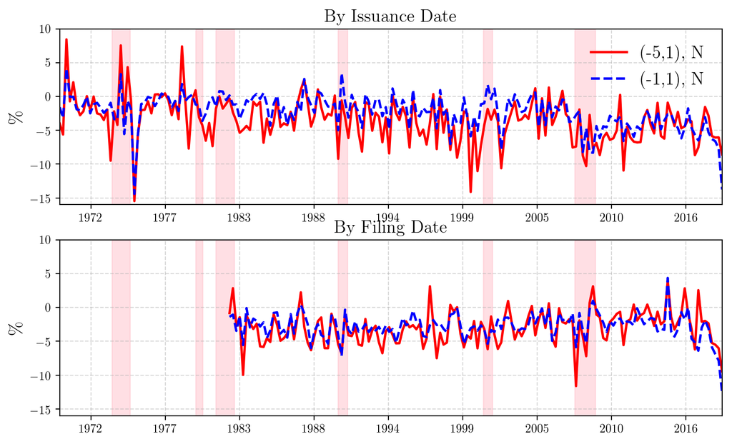

I did not find very significant cyclicality...